# Laboratório 3 Parte 1

Luiza Carvalho

## Problema

Essa primeira etapa o objetivo é entender os dados e pensar em atributos que podem ajudar na classificação. Lembre-se que grande parte do sucesso de uma tarefa de predição está na escolha de bons atributos. De forma concreta:

*Gere uma visualização que mostre em que ano houve mais evasões;

*Gere uma visualização da distribuição das classes (número de instâncias de cada classe nos dados);

*Há desbalanceamento das classes (isto é, uma classe tem muito mais instâncias que outra)? Em que proporção? Quais efeitos colaterais o desbalancemanento de classes pode causar no classificador?

*Crie pelo menos um atributo novo, que não seja a média da disciplina, que você acha que pode ajudar na classificação.

*Descreva-o e diga por que você acha que pode ser uma boa ideia usá-lo; Compare visualmente a distribuição desse atributo em cada classe (e.g. usando boxplots): elas parecem ser diferentes? O que ajuda mais o classificador, atributos que tem distribuições de valores diferentes entre as classes ou distribuições parecidas? Por que?

### Gerando Visualização das evasões

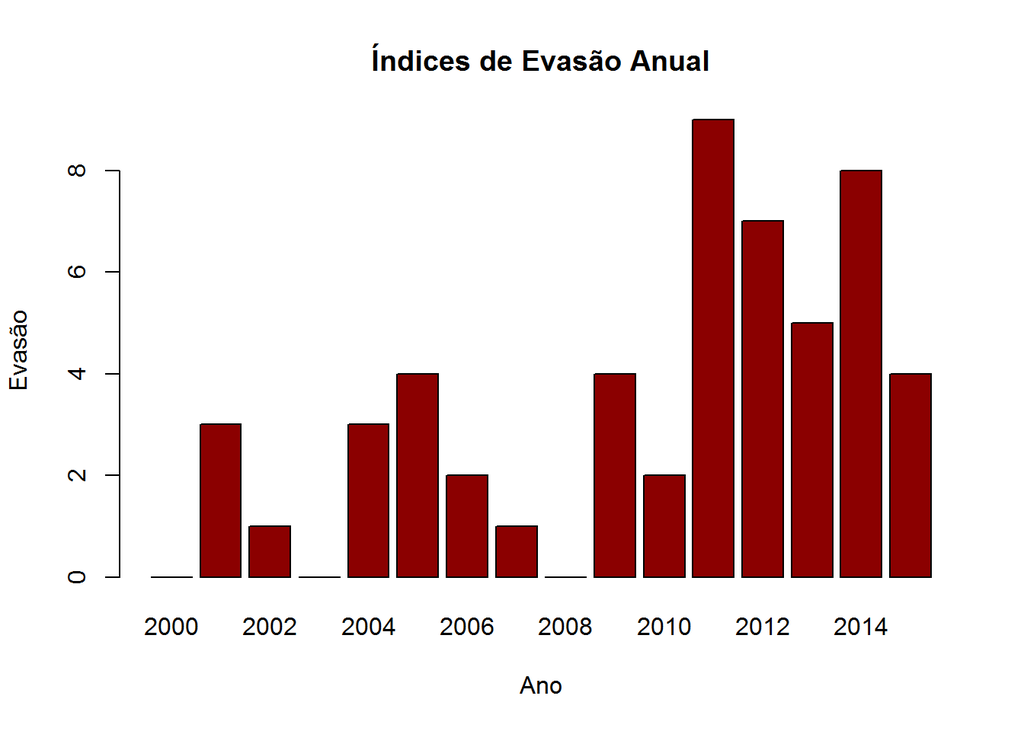

```r
# Importando os dados
treino <- read.csv('treino_classificacao.csv',header=T,na.strings=c(""))

# Criando um data frame para a ocorrência de evasões por ano
ano_subset <- subset(treino,select=c(1,4,7))
colnames(ano_subset) <- c("matr", "ano", "evasao")

#Substituimos o valor booleano por um numérico
library(plyr)
ano_subset$evasao <- as.character(ano_subset$evasao)
ano_subset$evasao <- revalue(ano_subset$evasao, c("FALSE"="0"))
ano_subset$evasao <- revalue(ano_subset$evasao, c("TRUE"="1"))

#Removemos valores repetidos de evasão do mesmo aluno
ano_subset <- unique(ano_subset)
ano_subset <- subset(ano_subset, select=c(2,3))
ano_subset$evasao <- as.integer(ano_subset$evasao)

#Somamos os valores numéricos para encontrar quantas evasões existiram por ano
ano_subset <- ddply(ano_subset, .(ano), summarize, evasao = sum(evasao))


barplot(ano_subset$evasao,
  main = "Índices de Evasão Anual",
  xlab = "Ano",
  ylab = "Evasão",
  names.arg = ano_subset$ano,
  col = "darkred")
```

Desse modo podemos observar que o ano que contém maior evasão é o de 2011, com 9 evasões no total.

### Visualização da Distribuição de Classes